# Using Linear Programming to Assemble an NBA Team

In this project, I use a linear programming model to assemble an NBA team. Specifically, I am interesting in maximizing the sum of some metric for the selected players on the team, while being constrained by the league salary cap and general positional requirements for building an effective team.

```r
# Set-up
rm(list = ls())
if (!require("pacman")) install.packages("pacman")
pacman::p_load(
  tidyverse,
  lubridate,
  magrittr,
  readxl,
  writexl,
  survival,
  zoo,
  tidyr,
  stringr,
  janitor,
  readr,
  data.table,
  lpSolve,
  nbapalettes,
  httr,
  XML,
  tidytext,
  extrafont
)

# Directories
INPUT <- "./input/"
INTERMEDIATE <- "./intermediate/"
OUTPUT <- "./output/"

# Constants
DATE <- Sys.Date()
```

### Data

I downloaded data from the website [Basketball Reference](https://www.basketball-reference.com). Specifically, I downloaded two data sets: one is a data set containing advanced stats for each player in the 2022-23 season, and another provides player contracts from the 2023-24 season on. Thus, I am building my team based on performance from this past season (2022-23), but assuming players are paid their salary for the current (2023-24) season.

```r
# Data on stats for players
data_stats <- read_csv(
  paste0(INPUT, "data_advanced_stats.csv"),
  skip = 1
) %>%
  clean_names() %>%
  select(-c(x1, rk)) %>%
  select(index = player_additional, everything()) %>%
  arrange(index)
```

```r
# Data on salaries for players
data_salary <- read_csv(
  paste0(INPUT, "data_salary.csv"),
  skip = 2
) %>%
  clean_names() %>%
  rename_at(
    vars(starts_with("x20")), ~paste0("salary_", str_sub(., 2))
  ) %>%
  mutate(
    across(contains("salary"), ~as.numeric(gsub("\\$", "", .)))
  ) %>%
  select(index = x9999, everything()) %>%
  select(-c(x1, rk, guaranteed)) %>%
  arrange(index)
```

```r
head(data_stats)
```

| index | player | pos | age | tm | g | mp | per | ts_percent | x3p_ar | f_tr | orb_percent | drb_percent | trb_percent | ast_percent | stl_percent | blk_percent | tov_percent | usg_percent | x21 | ows | dws | ws | ws_48 | x26 | obpm | dbpm | bpm | vorp |
| --- | --- | --- | --- | --- | --- | --- | --- | --- | --- | --- | --- | --- | --- | --- | --- | --- | --- | --- | --- | --- | --- | --- | --- | --- | --- | --- | --- | --- |
| achiupr01 | Precious Achiuwa | C | 23 | TOR | 55 | 1140 | 15.2 | 0.554 | 0.267 | 0.307 | 9.3 | 24.4 | 16.3 | 6.3 | 1.3 | 2.6 | 11.4 | 19.4 | NA | 0.8 | 1.4 | 2.2 | 0.093 | NA | -1.4 | -0.8 | -2.3 | -0.1 |
| adamsst01 | Steven Adams | C | 29 | MEM | 42 | 1133 | 17.5 | 0.564 | 0.004 | 0.490 | 20.1 | 25.3 | 22.7 | 11.2 | 1.5 | 3.7 | 19.8 | 14.6 | NA | 1.3 | 2.1 | 3.4 | 0.144 | NA | -0.3 | 0.9 | 0.6 | 0.7 |
| adebaba01 | Bam Adebayo | C | 25 | MIA | 75 | 2598 | 20.1 | 0.592 | 0.011 | 0.361 | 8.0 | 23.6 | 15.5 | 15.9 | 1.7 | 2.4 | 12.7 | 25.2 | NA | 3.6 | 3.8 | 7.4 | 0.137 | NA | 0.8 | 0.8 | 1.5 | 2.3 |
| agbajoc01 | Ochai Agbaji | SG | 22 | UTA | 59 | 1209 | 9.5 | 0.561 | 0.591 | 0.179 | 3.9 | 6.9 | 5.4 | 7.5 | 0.6 | 1.0 | 9.0 | 15.8 | NA | 0.9 | 0.4 | 1.3 | 0.053 | NA | -1.7 | -1.4 | -3.0 | -0.3 |
| aldamsa01 | Santi Aldama | PF | 22 | MEM | 77 | 1682 | 13.9 | 0.591 | 0.507 | 0.274 | 5.4 | 18.0 | 11.7 | 7.6 | 1.3 | 2.6 | 9.3 | 16.0 | NA | 2.1 | 2.4 | 4.6 | 0.130 | NA | -0.3 | 0.8 | 0.5 | 1.1 |
| alexani01 | Nickeil Alexander-Walker | SG | 24 | TOT | 59 | 884 | 11.6 | 0.565 | 0.539 | 0.203 | 1.9 | 10.5 | 6.3 | 16.7 | 1.7 | 2.0 | 14.6 | 17.9 | NA | 0.3 | 0.8 | 1.1 | 0.062 | NA | -1.4 | 0.4 | -0.9 | 0.2 |

```r
head(data_salary)
```

| index | player | tm | salary_2023_24 | salary_2024_25 | salary_2025_26 | salary_2026_27 | salary_2027_28 | salary_2028_29 |
| --- | --- | --- | --- | --- | --- | --- | --- | --- |
| achiupr01 | Precious Achiuwa | NYK | 4379527 | NA | NA | NA | NA | NA |
| adamsst01 | Steven Adams | MEM | 12600000 | 12600000 | NA | NA | NA | NA |
| adebaba01 | Bam Adebayo | MIA | 32600060 | 34848340 | 37096620 | NA | NA | NA |
| agbajoc01 | Ochai Agbaji | UTA | 4114200 | 4310280 | 6383525 | NA | NA | NA |
| aldamsa01 | Santi Aldama | MEM | 2194200 | 3960531 | NA | NA | NA | NA |
| alexani01 | Nickeil Alexander-Walker | MIN | 4687500 | 4312500 | NA | NA | NA | NA |

### Model Structure

I consider two versions of the model: one that maximizes BPM (Box Plus/Minus), and another that maximizes VORP (Value Over Replacement Player). Generally, both are estimates of a player’s overall contribution to his team, but since they are still different statistics, I would like to consider them both.

Constraint-wise, the total payroll of the team must fall under the 2023-24 salary of $136 M[^1]. Additionally, I would like to have at least two of every position (PG, SG, SF, PF, and C) on the team, but the 5 players in the starting lineup must represent all 5 positions. Furthermore, NBA rosters are limited to 15 players.[^2]

The variables in the model are:

1. $s_i$ (integer): binary variables that indicates where player $i$ is included in the starting lineup
2. $b_i$ (integer): binary variables that indicates where player $i$ is included as a bench player
3. $c_i$ (continuous): measure of value (either BPM or VORP) for player $i$
4. $salary_i$ (continuous): 2023-24 salary for player $i$
5. $position_{i,j}$ (integer): whether player $i$ plays position $j$

Where $n$ is the number of eligible players for the team.

The resulting model is thus:
$$max\sum_{i
= 1} ^ {n} c_is_i + c_ib_i$$

```r
# Prep data for LP
lp_data <- data_stats %>%
  # Duplicates for players with multiple teams: take "TOT" (total) for LP
  group_by(index) %>%
  mutate(ct = n()) %>%
  ungroup() %>%
  filter(ct == 1 | tm == "TOT") %>%
  left_join(data_salary %>%
              select(-c(tm, player)) %>%
              distinct()) %>%
  # Consider:
  ## Only players with salary data
  ## Played 100 or minutes in the 2022-23 season
  filter(!is.na(salary_2023_24),
         mp >= 100) %>%
  # For position, if player has multiple positions listed, assume first is the position they play more
  mutate(pos = gsub("-.*", "", pos)) %>%
  select(index, player, pos, bpm, vorp, salary = salary_2023_24)
```

```r
head(lp_data)
```

| index | player | pos | bpm | vorp | salary |
| --- | --- | --- | --- | --- | --- |
| achiupr01 | Precious Achiuwa | C | -2.3 | -0.1 | 4379527 |
| adamsst01 | Steven Adams | C | 0.6 | 0.7 | 12600000 |
| adebaba01 | Bam Adebayo | C | 1.5 | 2.3 | 32600060 |
| agbajoc01 | Ochai Agbaji | SG | -3.0 | -0.3 | 4114200 |
| aldamsa01 | Santi Aldama | PF | 0.5 | 1.1 | 2194200 |
| alexani01 | Nickeil Alexander-Walker | SG | -0.9 | 0.2 | 4687500 |

To solve the mode, I use the package `lpSolve`.[^3]

### Solving

```r
#----- Set-up -----#
solve.lp <- function(metric) {
  n <- nrow(lp_data)
  salary_cap <- 136e6
  salary_cap_bench_pct <- 0.25

  player_positions <- lp_data %>%
    mutate(n = 1) %>%
    pivot_wider(names_from = pos, values_from = n, values_fill = list(n = 0),
                names_glue = "pos_{pos}") %>%
    clean_names() %>%
    select(contains("pos_"))
  mat_player_pos <- t(player_positions)

  #----- Objective function -----#

  # Create coefficient vectors for each component
  coef_s <- lp_data[, metric] %>% pull()  # coefficients for s_i
  coef_b <- lp_data[, metric] %>% pull()  # coefficients for b_i

  # Combine the coefficient vectors to form the complete objective function
  obj <- c(coef_s, coef_b)

  #----- Constraints -----#

  # Constraint 1: salary (entire team)
  salary_s <- lp_data$salary
  salary_b <- lp_data$salary
  cons1_mat <- matrix(c(salary_s, salary_b), nrow = 1)
  cons1_dir <- "<="
  cons1_rhs <- salary_cap

  # Constraint 2: salary (bench)
  cons2_mat <- matrix(c(numeric(n), salary_b), nrow = 1)
  cons2_dir <- "<="
  cons2_rhs <- salary_cap*salary_cap_bench_pct

  # Constraint 3: number of starters
  cons3_mat <- matrix(c(rep(1, n), numeric(n)), nrow = 1)
  cons3_dir <- "="
  cons3_rhs <- 5

  # Constraint 4: number of players
  cons4_mat <- matrix(c(rep(1, n), rep(1, n)), nrow = 1)
  cons4_dir <- "<="
  cons4_rhs <- 15

  # Constraint 5: all 5 positions in starting lineup
  cons5_mat <- cbind(mat_player_pos, matrix(nrow = 5, ncol = n))
  cons5_dir <- "="
  cons5_rhs <- 1

  # Constraint 6: At least 2 of every position on team
  cons6_mat <- cbind(mat_player_pos, mat_player_pos)
  cons6_dir <- ">="
  cons6_rhs <- 2

  # Constraint 7: no player can both be a starter and bench player
  cons7_mat <- cbind(diag(n), diag(n))
  cons7_dir <- "<="
  cons7_rhs <- 1

  # Constraint 8: no more than 4 players from the same position on the team
  cons8_mat <- cbind(mat_player_pos, mat_player_pos)
  cons8_dir <- "<="
  cons8_rhs <- 4


  #----- Solve -----#
  cons_all <- rbind(
    cons1_mat,
    cons2_mat,
    cons3_mat,
    cons4_mat,
    cons5_mat,
    cons6_mat,
    cons7_mat,
    cons8_mat
  )

  dir_all <- c(
    rep(cons1_dir, nrow(cons1_mat)),
    rep(cons2_dir, nrow(cons2_mat)),
    rep(cons3_dir, nrow(cons3_mat)),
    rep(cons4_dir, nrow(cons4_mat)),
    rep(cons5_dir, nrow(cons5_mat)),
    rep(cons6_dir, nrow(cons6_mat)),
    rep(cons7_dir, nrow(cons7_mat)),
    rep(cons8_dir, nrow(cons8_mat))
  )

  rhs_all <- c(
    rep(cons1_rhs, nrow(cons1_mat)),
    rep(cons2_rhs, nrow(cons2_mat)),
    rep(cons3_rhs, nrow(cons3_mat)),
    rep(cons4_rhs, nrow(cons4_mat)),
    rep(cons5_rhs, nrow(cons5_mat)),
    rep(cons6_rhs, nrow(cons6_mat)),
    rep(cons7_rhs, nrow(cons7_mat)),
    rep(cons8_rhs, nrow(cons8_mat))
  )

  solution <- lp("max", obj, cons_all, dir_all, rhs_all, all.bin = T)
  solution_index <- solution$solution
  solution_players <- rbind(lp_data, lp_data)[solution_index == 1, ]
  solution_players %<>%
    mutate(role = ifelse(row_number() <= 5, "starter", "bench player"))

  return(solution_players)
}

team_bpm <- solve.lp("bpm")
team_vorp <- solve.lp("vorp")
```

A team optimized for **BPM** looks like:

| role | player | pos | bpm | vorp | salary |
| --- | --- | --- | --- | --- | --- |
| starter | Nikola Jokić | C | 13.0 | 8.8 | 47607350 |
| starter | Kyle Anderson | PF | 2.5 | 2.2 | 9219512 |
| starter | Luka Dončić | PG | 8.9 | 6.6 | 40064220 |
| starter | Trey Murphy III | SF | 1.8 | 2.3 | 3359280 |
| starter | Desmond Bane | SG | 3.5 | 2.5 | 3845083 |
| bench player | Walker Kessler | C | 2.9 | 2.1 | 2831160 |
| bench player | Boban Marjanović | C | 1.6 | 0.2 | 2019706 |
| bench player | Xavier Tillman Sr. | C | 1.9 | 1.2 | 1930681 |
| bench player | Jae Crowder | PF | 1.2 | 0.3 | 2019706 |
| bench player | Kris Dunn | PG | 2.4 | 0.6 | 2586665 |

[output cut: 4 more lines]

A team optimized for **VORP** for looks like:

| role | player | pos | bpm | vorp | salary |
| --- | --- | --- | --- | --- | --- |
| starter | Nikola Jokić | C | 13.0 | 8.8 | 47607350 |
| starter | Evan Mobley | PF | 1.7 | 2.5 | 8882640 |
| starter | Luka Dončić | PG | 8.9 | 6.6 | 40064220 |
| starter | Trey Murphy III | SF | 1.8 | 2.3 | 3359280 |
| starter | Immanuel Quickley | SG | 1.7 | 2.1 | 4171548 |
| bench player | Walker Kessler | C | 2.9 | 2.1 | 2831160 |
| bench player | Mason Plumlee | C | 2.2 | 2.2 | 5000000 |
| bench player | Alperen Şengün | C | 1.4 | 1.9 | 3536280 |
| bench player | Santi Aldama | PF | 0.5 | 1.1 | 2194200 |
| bench player | Jordan Goodwin | PG | 0.7 | 0.8 | 1927896 |

[output cut: 5 more lines]

### Analysis of Results

To get a sense for how strong of a team the program assembled, I compare the team minutes-per-game weighted average BPM/VORP of the program generated team to the rest of the NBA. But before this comparison can be performed, I must allocate how many minutes I expect players on the program generated team to play. To do this, I assume the team uses a 10 player rotation (i.e., only 10 players on the team actually play), in line with a typical 8-10 player rotation.[^4] I will assume the players that are part of the rotation are the top two players at each position (in terms of the metric optimized). I will assign minutes to each player by multiplying the length of an NBA game (48 minutes) by the player’s share of total BPM/VORP at that position.[^5] I will also bound the most minutes a player can play at 35 minutes, which is roughly around the most a player will play in a game.[^6]

```r
# Combine teams into one dataframe
team_all <- rbind(
  team_bpm %>%
    select(index:pos, role, metric = bpm) %>%
    mutate(lp_team = "bpm"),
  team_vorp %>%
    select(index:pos, role, metric = vorp) %>%
    mutate(lp_team = "vorp")
)

# Calculate MPG
NBA_GAME_LENGTH <- 48
MPG_MAX <- 35
mpg_lp <- team_all %>%
  group_by(lp_team, pos) %>%
  slice_max(metric, n = 2) %>%
  ungroup() %>%
  group_by(lp_team, pos) %>%
  mutate(mpg = metric/sum(metric) * NBA_GAME_LENGTH) %>%
  ungroup() %>%
  mutate(mpg = case_when(
    mpg >= MPG_MAX ~ MPG_MAX,
    mpg <= NBA_GAME_LENGTH - MPG_MAX ~ NBA_GAME_LENGTH - MPG_MAX,
    T ~ mpg
  ))

# Add onto team dataframe
team_all %<>%
  left_join(mpg_lp) %>%
  mutate(mpg = replace_na(mpg, 0)) %>%
  select(lp_team, everything())
```

```r
# Calculate MPG-weighted means
mpg_avg <- team_all %>%
  group_by(lp_team) %>%
  summarize(team_avg = weighted.mean(metric, mpg)) %>%
  ungroup()
```

The minutes each player plays:

| lp_team | index | player | pos | role | metric | mpg |
| --- | --- | --- | --- | --- | --- | --- |
| bpm | anderky01 | Kyle Anderson | PF | starter | 2.5 | 32.43243 |
| bpm | banede01 | Desmond Bane | SG | starter | 3.5 | 32.30769 |
| bpm | doncilu01 | Luka Dončić | PG | starter | 8.9 | 26.53416 |
| bpm | jokicni01 | Nikola Jokić | C | starter | 13.0 | 35.00000 |
| bpm | murphtr02 | Trey Murphy III | SF | starter | 1.8 | 30.85714 |
| bpm | crowdja01 | Jae Crowder | PF | bench player | 1.2 | 15.56757 |
| bpm | dunnkr01 | Kris Dunn | PG | bench player | 2.4 | 0.00000 |
| bpm | halibty01 | Tyrese Haliburton | PG | bench player | 7.2 | 21.46584 |
| bpm | hausesa01 | Sam Hauser | SF | bench player | 1.0 | 17.14286 |
| bpm | kesslwa01 | Walker Kessler | C | bench player | 2.9 | 13.00000 |

[output cut: 19 more lines]

The MPG-weighted means:

| lp_team | team_avg |
| --- | --- |
| bpm | 4.981707 |
| vorp | 3.805635 |

### Visualization

A visualization of a comparison of the model’s team against the rest of the NBA (the top 10 for each metric):

```r
# Get average for each team
team_avg <- data_stats %>%
  filter(mp >= 100) %>%  # Only players with more than 100 minutes played
  mutate(mpg = mp/g) %>%
  filter(tm != "TOT") %>%
  group_by(tm) %>%
  summarize(bpm  = weighted.mean(bpm, mpg),
            vorp = weighted.mean(vorp, mpg)) %>%
  ungroup() %>%
  pivot_longer(c(bpm, vorp), names_to = "metric", values_to = "weighted_avg") %>%
  rbind(
    mpg_avg %>%
      mutate(tm = "Linear Program") %>%
      rename(metric = lp_team, weighted_avg = team_avg)
  )

# Get team names for abbreviations
url <- "https://en.wikipedia.org/wiki/Wikipedia:WikiProject_National_Basketball_Association/National_Basketball_Association_team_abbreviations"
request <- GET(url)
tables <- readHTMLTable(doc=content(request, "text"))

team_names <- as.data.frame(tables[1]) %>%
  filter(row_number() > 1) %>%
  rename(abbr = 1, name = 2) %>%
  mutate(abbr = str_sub(abbr, 1, 3)) %>%
  rowwise() %>%
  mutate(name = word(name, -1)) %>%
  ungroup()

# Add on team colors for plot
team_colors <- available_palettes() %>%
  filter(teams == palette_names) %>%
  mutate(color = gsub(",.*", "", palette_colors)) %>%
  select(name = teams, color) %>%
  mutate(name = recode(name, "sixers" = "76ers"),
         name = str_to_title(name))

team_names %<>%
  left_join(team_colors)
```

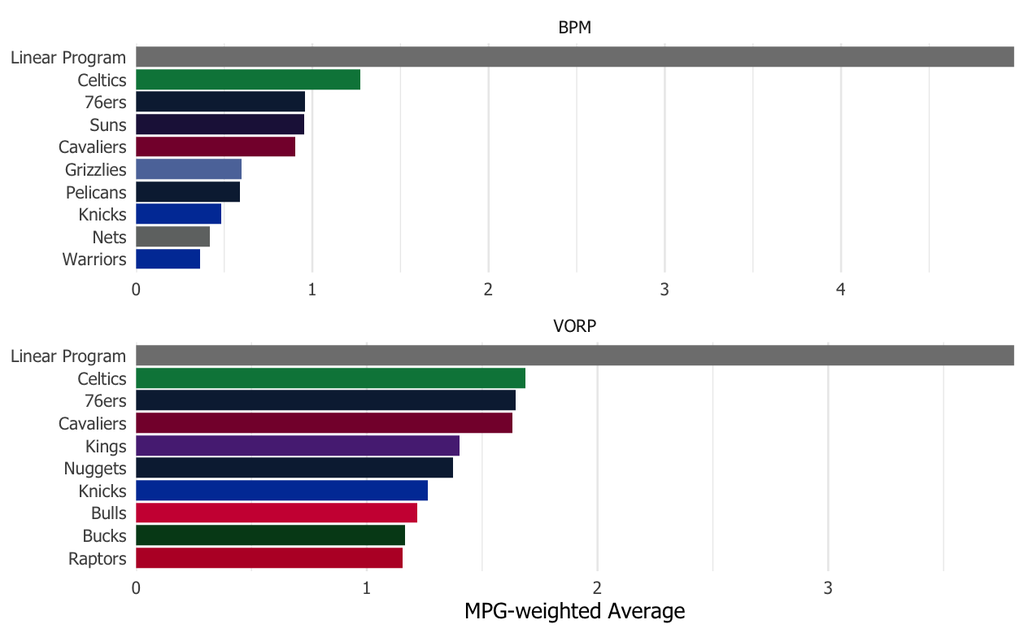

```r
# Dataframe for plotting
plot_df <- team_avg %>%
  mutate(tm = recode(tm,
                     "BRK" = "BKN",
                     "CHO" = "CHA",
                     "PHO" = "PHX")) %>%
  left_join(team_names, by = c("tm" = "abbr")) %>%
  mutate(
    name  = ifelse(tm == "Linear Program", "Linear Program", name),
    color = ifelse(tm == "Linear Program", "#7F7F7F", color)
  ) %>%
  group_by(metric) %>%
  slice_max(weighted_avg, n=10) %>%
  ungroup() %>%
  mutate(name = reorder_within(name, weighted_avg, metric),
         metric = toupper(metric))

# Plot
ggplot(plot_df) +
  geom_bar(aes(weighted_avg, name, fill = color), stat = "identity") +
  facet_wrap(~metric, scales = "free", ncol = 1) +
  theme_minimal() +
  scale_y_reordered() +
  scale_x_continuous(expand = c(0, 0)) +
  scale_fill_identity() +
  theme(
    axis.title.y = element_blank(),
    panel.grid.major.y = element_blank(),
    text = element_text(family = "Tahoma")
  ) +
  labs(x = "MPG-weighted Average")
```

As the plot above shows, the team created by our model has a far greater average BPM/VORP than any other team in the NBA. However, it would be helpful to assess how relevant this is to a team’s win/loss record. To do this, I see how correlated MPG-weighted BPM/VORP is to a team’s winning percentage.

```r
# Standings data
data_standings <- read_csv(
  paste0(INPUT, "data_standings.csv"),
  skip = 2
) %>%
  clean_names() %>%
  select(team, overall) %>%
  mutate(win_pct = as.numeric(gsub("-.*", "", overall))/82) %>%
  select(team, win_pct) %>%
  rowwise() %>%
  mutate(team = word(team, -1)) %>%
  ungroup() %>%
  left_join(team_names, by = c("team" = "name")) %>%
  select(-color) %>%
    mutate(abbr = recode(abbr,
                     "BKN" = "BRK",
                     "CHA" = "CHO",
                     "PHX" = "PHO")) %>%
  left_join(team_avg, by = c("abbr" = "tm")) %>%
  pivot_wider(names_from = metric, values_from = weighted_avg) %>%
  select(-abbr)
```

```r
data_standings
```

| team | win_pct | bpm | vorp |
| --- | --- | --- | --- |
| Bucks | 0.7073171 | 0.19161666 | 1.164701867 |
| Celtics | 0.6951220 | 1.27270491 | 1.687641777 |
| 76ers | 0.6585366 | 0.95603587 | 1.646310638 |
| Nuggets | 0.6463415 | -0.10301252 | 1.374199175 |
| Cavaliers | 0.6219512 | 0.90355283 | 1.631226186 |
| Grizzlies | 0.6219512 | 0.59808352 | 1.087121316 |
| Kings | 0.5853659 | 0.14472370 | 1.403070653 |
| Knicks | 0.5731707 | 0.48469922 | 1.263583856 |
| Nets | 0.5487805 | 0.41714728 | 0.891061029 |
| Suns | 0.5487805 | 0.95284885 | 0.889852013 |

[output cut: 20 more lines]

```r
# Correlation - BPM
cor.test(data_standings$win_pct, data_standings$bpm)
```

```
    Pearson's product-moment correlation

data:  data_standings$win_pct and data_standings$bpm
t = 10.538, df = 28, p-value = 2.986e-11
alternative hypothesis: true correlation is not equal to 0
95 percent confidence interval:
 0.7866843 0.9485447
sample estimates:
     cor
0.893671
```

```r
# Correlation - VORP
cor.test(data_standings$win_pct, data_standings$vorp)
```

```
    Pearson's product-moment correlation

data:  data_standings$win_pct and data_standings$vorp
t = 11.769, df = 28, p-value = 2.351e-12
alternative hypothesis: true correlation is not equal to 0
95 percent confidence interval:
 0.8218343 0.9576556
sample estimates:
      cor
0.9120595
```

There is a strong positive correlation between a team’s winning percentage and each of our calculated metrics. Thus, it is probably fair to say that either team generated by the linear program would win a lot of games!

[^1]: *See* https://www.spotrac.com/nba/cap/
[^2]: *See* https://en.wikipedia.org/wiki/List_of_current_NBA_team_rosters#cite_note-1
[^3]: *See* https://cran.r-project.org/web/packages/lpSolve/index.html
[^4]: *See* https://gamefaqs.gamespot.com/boards/2000208-sports-and-racing-nba/66049885
[^5]: *See* https://official.nba.com/rule-no-5-scoring-and-timing/
[^6]: *See* https://www.espn.com/nba/seasonleaders/_/league/nba/sort/avgMinutes/year/2023